# How Medications and Medication Regimens relate to Patient Mortality

Author

Rebecca Basta and Riley Herber

**Authors**

- Rebecca Basta and Riley Herber These authors contributed equally to this work.

**Author affiliations**

1. University of Georgia, Athens, GA, USA.

# 1 Summary/Abstract

Throughout this project we examined how different medication and medication regimens relate to patient mortality. We first cleaned and organized the MIMIC-IV dataset to be able to create a synthetic dataset based on the original due to the confidentiality of the MIMIC-IV dataset. We then used the synthetic dataset to look at the relationship between medication use and patient mortality. Our results showed that patients receiving insulin or ACE inhibitors had lower unadjusted mortality rates, whereas patients receiving anticoagulants, diuretics, antiplatelets, or statins had higher unadjusted mortality. The higher unadjusted mortality may be due to patients having comorbidities.

# 2 Introduction

This information is important because it can help healthcare providers better understand the effects of commonly prescribed medications on patient survival. Identifying medications that are associated with improved or worsened outcomes may guide clinical decision-making, optimize treatment strategies, and ultimately improve patient care and safety.

## 2.1 General Background Information

Medications are a cornerstone of modern clinical care, particularly in hospitalized and critically ill populations where patients frequently receive multiple therapies simultaneously. This concurrent use of multiple medications, commonly referred to as polypharmacy, has become increasingly prevalent, especially among older adults and patients with chronic or complex conditions. While necessary for managing multiple comorbidities, polypharmacy introduces risks such as drug–drug interactions, adverse effects, and challenges in clinical decision-making. Large-scale epidemiological studies have demonstrated that polypharmacy is not only common but also associated with higher mortality, hospitalization, and healthcare utilization. A nationwide cohort study published in Nature, analyzed over three million older patients and found a clear relationship between the number of medications one was taking and adverse outcomes. (Chang et al., 2020)(1) Another large-scale observation study looked at whether 30-day prescriptions or 90-day prescriptions were better for patient adherence after a heart attack. They found that those given the 90-day prescription are more likely to stay on their medication long-term compared to those given the 30-day prescription. There was about a 10% increase in adherence for statins, beta blockers, ACE inhibitors, and P2Y12 inhibitors. The authors suggested that this increase could be due to less pharmacy visits and a lower likelihood of patients missing a refill. (Rymer et al., 2020)(2) Observational data from electronic health records (EHRs), such as MIMIC-IV, provide a valuable platform to explore these relationships. These datasets include detailed patient demographics, medication prescriptions, and clinical outcomes, allowing researchers to examine patterns across large, diverse patient populations. However, interpreting these data requires caution: unadjusted associations between medication use and mortality may reflect underlying patient severity rather than direct drug effects.

In this study, we examine how individual medication classes, combinations of medications, and overall medication burden relate to 30-day mortality using a synthetic dataset derived from MIMIC-IV. By analyzing both class-specific and polypharmacy patterns, this work aims to provide insights into treatment-outcome relationships while highlighting the methodological challenges inherent in observational clinical research.

## 2.2 Description of data and data source

This study uses the MIMIC-IV (Medical Information Mart for Intensive Care) database to examine relationships between medication use and patient mortality. MIMIC-IV is a large, publicly available database containing de-identified health records from patients admitted to Beth Israel Deaconess Medical Center in Boston, Massachusetts.

The database includes detailed information on more than 65,000 ICU patients and over 200,000 emergency department visits. Available variables include:

patient demographics

hospital admissions and transfers

laboratory measurements

medication prescriptions and administration records

microbiology cultures

billing and procedure data

mortality outcomes

These data provide a rich resource for investigating relationships between treatment patterns and patient outcomes.

This dataset is then used as a reference to create a synthetic dataset based on the trends present in the real patient data in MIMIC-IV.

## 2.3 Questions/Hypotheses to be addressed

Our primary objective is to examine how different medications and medication regimens relate to patient mortality. This may include analyzing whether certain medications or combinations of medications are associated with higher or lower mortality rates. To analyze the relationship between medication, use and mortality in the MIMIC-IV dataset, we would first clean and organize medication and outcome data. We would then explore general patterns by comparing mortality rates across patients who received different medications or groups of medications. Simple summaries and visualizations could be used to identify trends or potential associations. This exploratory analysis would help generate initial insights and guide more detailed analyses later on.

# 3 Methods

## 3.1 Data Acquisition

Data were obtained from the MIMIC-IV database (version 3.1), a publicly available de-identified electronic health record dataset accessible through PhysioNet. Access to the database requires completion of a data use agreement and credentialing through PhysioNet.

The following tables from the hospital (hosp) module were used:

patients.csv – demographic information including age, sex, and date of death

admissions.csv – hospital admission and discharge information

prescriptions.csv – medication orders associated with each hospital admission

## 3.2 Data Processing and Cleaning

All data processing and analysis were performed using R. Raw CSV files were imported and cleaned prior to analysis.

Data cleaning steps included:

Removing admissions with a length of stay less than 0 days or greater than 365 days, as these were likely data entry errors.

Standardizing medication names by converting drug names to uppercase and removing extra whitespace.

Assigning medications to 13 pharmacological classes (e.g., antibiotics, opioids, vasopressors) using keyword matching.

Creating binary indicators for each medication class indicating whether at least one medication from that class was prescribed during a given admission.

Full data processing code is documented in:

code/processing-code/mimic-processing.qmd

Exploratory analysis code is available in:

code/eda-code/mimic-eda.qmd

Further analysis and model code is available in:

code/analysis-code/analysis-code.qmd

## 3.3 Statistical Analysis

This study focuses on exploratory, unadjusted analyses.

The following descriptive analyses were conducted:

Calculation of 30-day mortality rates

Distribution of patient ages and demographics

Medication class usage frequencies

Mortality rates stratified by medication class

Relationship between polypharmacy (number of medication classes) and mortality

Results are presented using summary tables and visualizations.

# 4 Results

## 4.1 Exploratory/Descriptive analysis

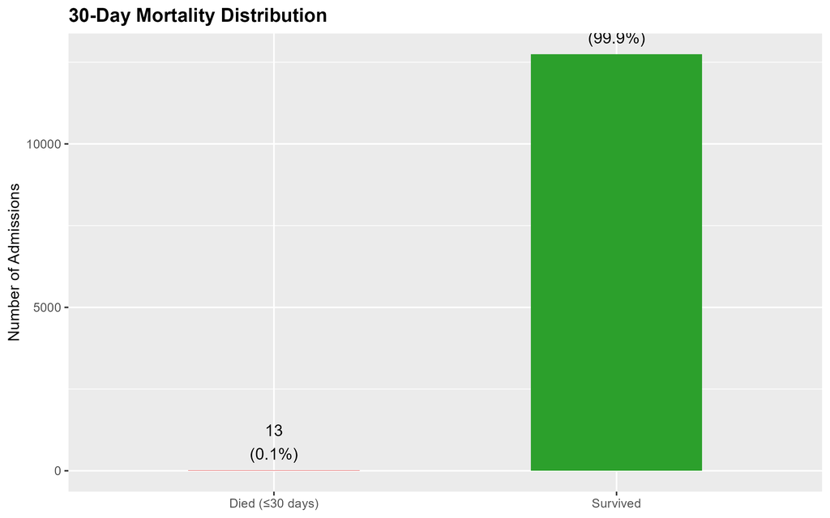

Figure 1: Distribution of 30-day mortality outcomes in the synthetic dataset

```r
library(here)
knitr::include_graphics(here("results", "figures", "day-30-mortality.png"))
```

The distribution of 30-day mortality in the synthetic dataset was highly imbalanced, with approximately 0.1% of admissions resulting in death (Figure 1). This extreme class imbalance has important implications for subsequent statistical modeling and evaluation metrics.

Medication use was relatively uniform across the six medication classes examined, with each class prescribed in approximately half of all admissions (Figure 2). Anticoagulants were the most frequently prescribed class (53.6%), while other classes ranged narrowly between 51.9% and 52.9%.

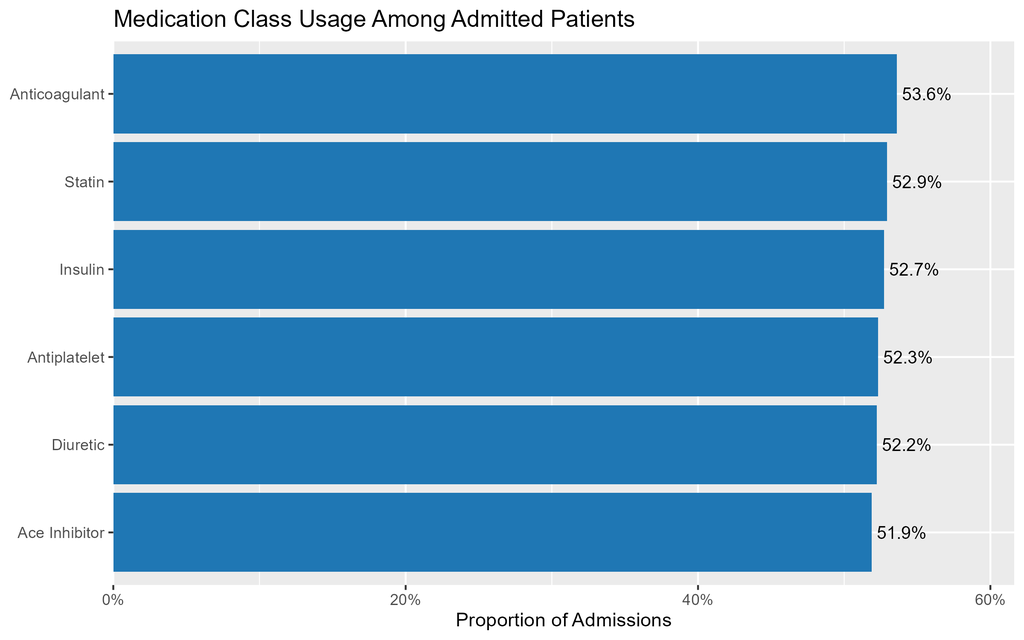

Figure 2: Medication Class Usage Among Admitted Patients, showing the proportion of hospital admissions associated with six common medication classes.

```r
knitr::include_graphics(here("results", "figures", "perscriptoin-frequency.png"))
```

Unadjusted comparisons of mortality rates by medication class revealed heterogeneous patterns (Figure 3). Insulin and ACE inhibitor use were associated with lower raw mortality rates compared to non-use, while anticoagulants, diuretics, antiplatelets, and statins were associated with higher mortality rates. These differences likely reflect confounding by indication rather than causal effects of medication exposure.

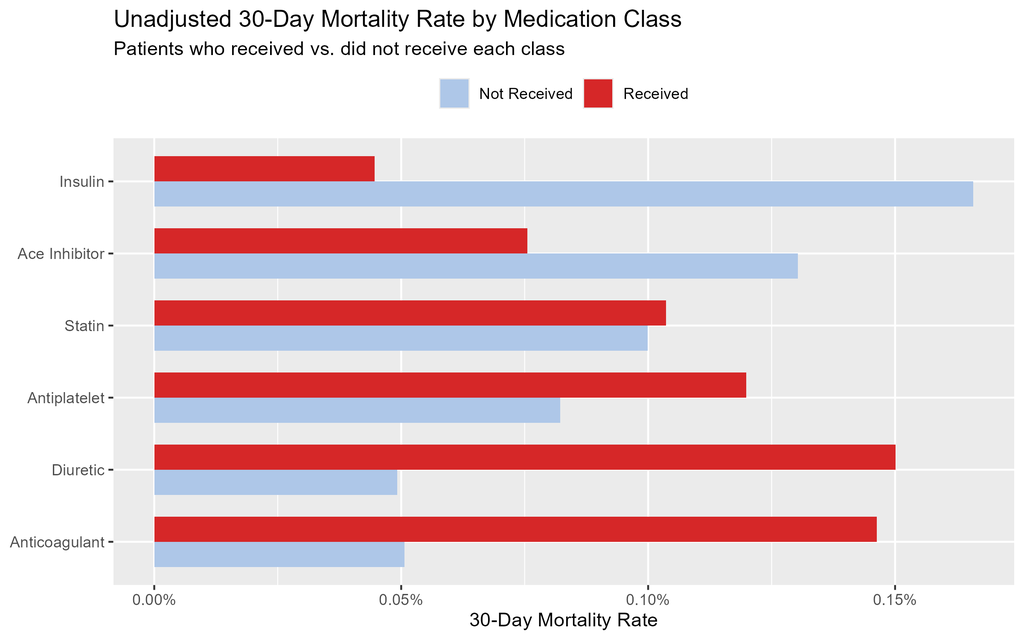

Figure 3: Unadjusted 30-day mortality rate by medication class, comparing patients who received versus did not receive each medication class during their hospital admission.

```r
knitr::include_graphics(here("results", "figures", "unadjusted-perscriptoin-frequency.png"))
```

Figure 3 reveals notably different mortality patterns depending on the medication class. Insulin and ACE inhibitors stand out as the only two classes where patients who received them had lower unadjusted 30-day mortality than those who did not, most strikingly for insulin, where recipients had a mortality rate near 0.05% compared to roughly 0.17% for non-recipients. In contrast, anticoagulants, diuretics, antiplatelets, and statins all show the opposite pattern, with recipients experiencing higher raw mortality rates than non-recipients.

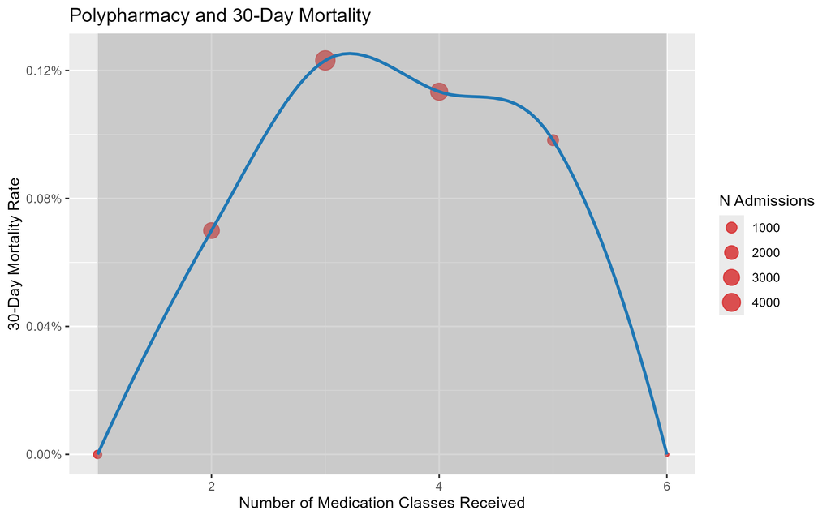

Figure 4: Unadjusted 30-day mortality rate by number of medication classes received during hospital admission, with point size scaled to the number of admissions in each group.

```r
knitr::include_graphics(here("results", "figures", "polypharmacy-frequency.png"))
```

Figure 4 displays a non-linear, inverted U-shaped relationship between polypharmacy and 30-day mortality. Mortality rises sharply from near 0% among patients receiving only one medication class to a peak of approximately 0.12% to 0.13% among those receiving three classes, then declines steadily through four and five classes before dropping back to near 0% among patients receiving all six classes. The point sizes indicate that the middle groups, particularly those receiving three to four medication classes, represent the largest share of admissions, lending more reliability to the estimates in that range. The near-zero mortality at both extremes is notable and warrants careful interpretation, as patients receiving very few or all six medication classes may represent highly distinct clinical subgroups, and the small sample sizes at those extremes make those estimates less stable. As with the previous figure, Further analysis would be necessary to determine whether the observed pattern reflects a true relationship between polypharmacy and mortality or is driven by differences in underlying patient characteristics across groups.

To complement the descriptive findings, a series of simple single-predictor logistic regression models were fit to quantify the unadjusted association between each exposure of interest and 30-day mortality. For each of the six medication classes, a separate logistic regression model was fit with the binary medication receipt indicator as the sole predictor of 30-day mortality. This approach provides odds ratios (ORs) and 95% confidence intervals (CIs) that are more interpretable than raw rate differences alone. In addition, logistic regression models were fit for age (continuous) and sex to characterize their individual unadjusted associations with the outcome. Finally, polypharmacy count (number of medication classes received) was modeled as a continuous predictor to formally test the trend observed in the descriptive analysis. All models were fit using the `glm()` function in R with a binomial family and logit link. Given the highly imbalanced outcome (approximately 0.1% mortality), results should be interpreted cautiously and no p-value threshold is used to designate statistical significance.

```r
table_data <- readRDS(here("results", "tables", "basic_logreg_results.rds"))
kable(table_data)
```

Table 1: Unadjusted odds ratios (95% CI) from single-predictor logistic regression models for 30-day mortality.

| Predictor | Term | OR | 95% CI Lower | 95% CI Upper | p-value |
| --- | --- | --- | --- | --- | --- |
| med_anticoagulant | med_anticoagulant | 2.889 | 0.883 | 12.891 | 0.1070 |
| med_statin | med_statin | 1.037 | 0.344 | 3.224 | 0.9480 |
| med_insulin | med_insulin | 0.269 | 0.060 | 0.878 | 0.0459 |
| med_antiplatelet | med_antiplatelet | 1.459 | 0.486 | 4.830 | 0.5080 |
| med_diuretic | med_diuretic | 3.053 | 0.933 | 13.621 | 0.0901 |
| med_ace_inhibitor | med_ace_inhibitor | 0.579 | 0.175 | 1.738 | 0.3390 |
| age | age | 0.985 | 0.955 | 1.015 | 0.3120 |
| gender | genderM | 0.447 | 0.121 | 1.372 | 0.1800 |
| n_med_classes | n_med_classes | 1.169 | 0.671 | 2.032 | 0.5800 |

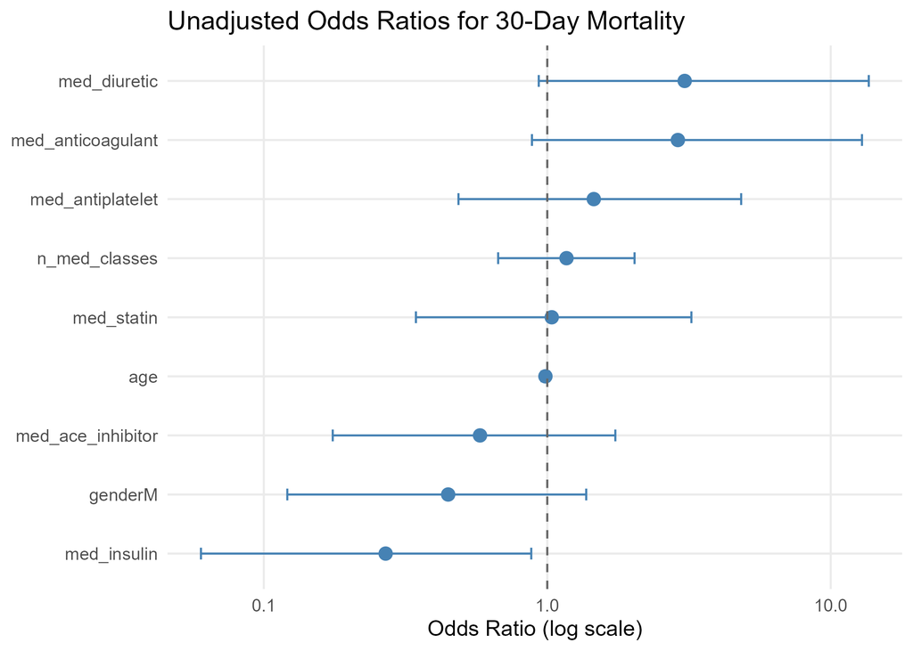

Figure 5: Forest plot of unadjusted odds ratios (95% CI) for 30-day mortality by predictor. ORs greater than 1 indicate higher odds of mortality; ORs less than 1 indicate lower odds. The dashed vertical line marks the null (OR = 1).

```r
knitr::include_graphics(here("results", "figures", "basic_logreg_forest.png"))
```

## 4.2 Full analysis

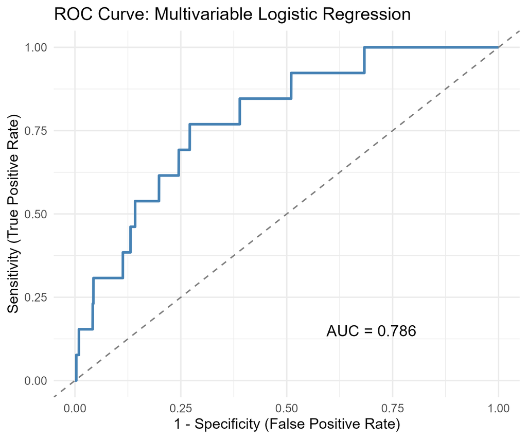

Figure 6: Receiver operating characteristic (ROC) curve for the multivariable logistic regression model predicting 30-day mortality. The AUC reflects the model’s ability to discriminate between survivors and non-survivors.

```r
knitr::include_graphics(here("results", "figures", "roc_curve.png"))
```

## 4.3 ML models and Cross-Validation Metrics

Multiple machine learning models were evaluated using 5-fold stratified cross-validation, including logistic regression, decision tree, random forest, gradient boosting, and two baseline models (age-only and medication-only).

As shown in Table 2, model discrimination was generally modest across all approaches. Logistic regression achieved the highest performance (AUC = 0.622), followed closely by the random forest model (AUC = 0.611). The age-only baseline model demonstrated comparable predictive ability (AUC = 0.584), while the medication-only model performed similarly (AUC = 0.584). The decision tree model performed at chance level (AUC = 0.500), and gradient boosting underperformed relative to simpler models (AUC = 0.465).

```r
ml_comp <- read_csv(here("results", "tables", "ml_model_comparison.csv"))
kable(ml_comp)
```

Table 2: Cross-validated performance of predictive models for 30-day mortality using demographic and medication features. Metrics include AUC-ROC, average precision, and Brier score.

| Model | Avg Precision | Brier Score | AUC-ROC |
| --- | --- | --- | --- |
| Logistic Regression | 0.9993 | 0.0010 | 0.6215 |
| Decision Tree | 0.9990 | 0.0010 | 0.5000 |
| Random Forest | 0.9993 | 0.0011 | 0.6107 |
| Gradient Boosting | 0.9990 | 0.0010 | 0.4654 |
| Age Only | 0.9993 | 0.0010 | 0.5845 |
| Medication Only | 0.9993 | 0.0010 | 0.5843 |

Medication-only models did not improve discrimination relative to age, suggesting limited independent predictive value of medication variables in isolation. Decision tree and gradient boosting models performed poorly, with AUC values of 0.500 and 0.465, respectively.

ROC curves and calibration plots (Figure 7 and Figure 8) further demonstrated limited model performance. While models were able to rank individuals slightly better than chance, predicted probabilities were heavily compressed near zero, reflecting both extreme class imbalance and limited feature informativeness.

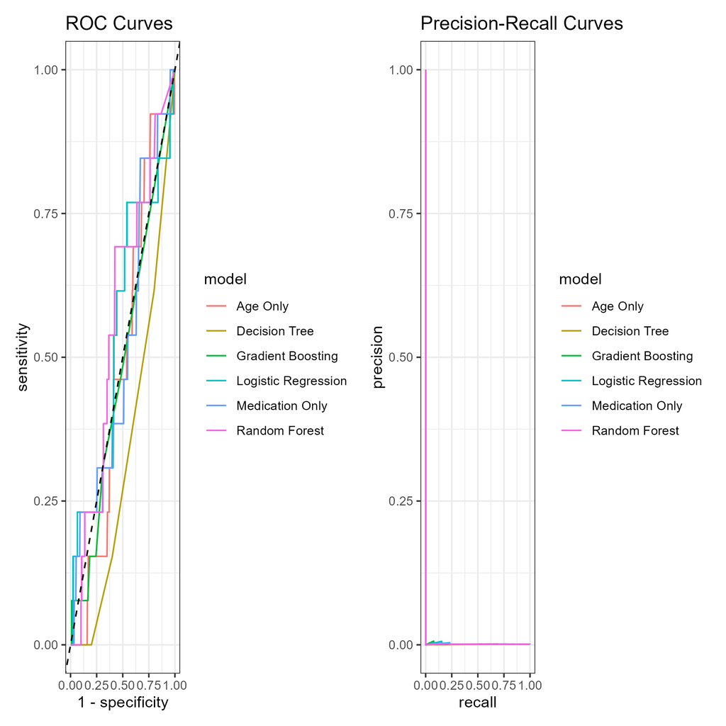

Figure 7: Receiver operating characteristic (ROC) curves for machine learning and baseline models predicting 30-day mortality, evaluated using 5-fold stratified cross-validation.

```r
knitr::include_graphics(here("results", "figures", "ml_roc_pr_curves.png"))
```

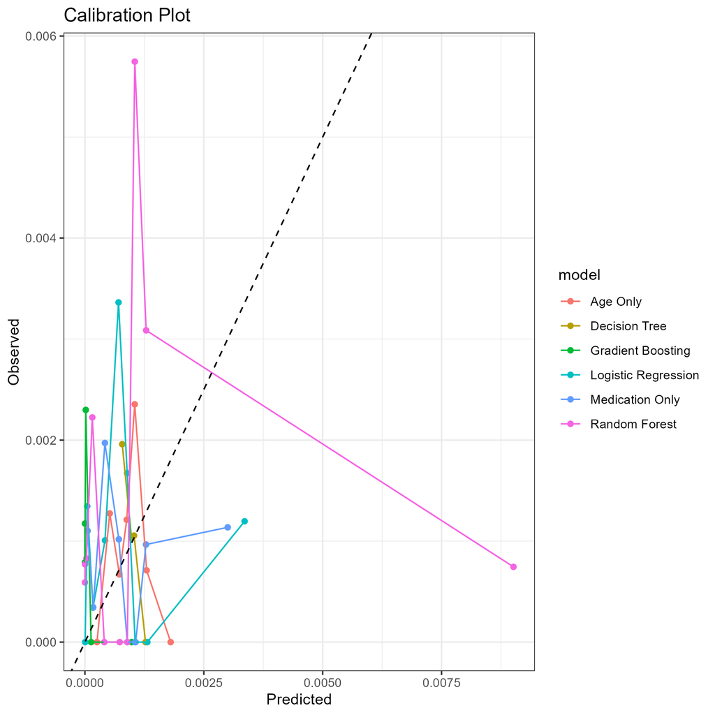

Figure 8: Calibration plot illustrating that all models produce highly compressed probability estimates, with limited spread in predicted 30-day mortality risk and modest alignment with observed outcomes.

```r
knitr::include_graphics(here("results", "figures", "ml_calibration.png"))
```

# 5 Discussion

## 5.1 Summary and Interpretation

Our study explored the associations between individual medication classes, polypharmacy, and 30-day mortality in a synthetic dataset modeled after MIMIC-IV. Descriptive analyses revealed that patients receiving insulin or ACE inhibitors had lower unadjusted mortality rates, whereas patients receiving anticoagulants, diuretics, antiplatelets, or statins had higher unadjusted mortality. Polypharmacy displayed a non-linear, inverted U-shaped relationship with mortality, with intermediate levels of medication use corresponding to the highest observed risk.

These findings are consistent with prior research. Large-scale cohort studies, including Scientific Reports 2020, demonstrate that increasing numbers of medications are associated with progressively higher risks of mortality, but that the impact varies by drug type and patient context. (Chang et al., 2020)(1) Similarly, JAHA 2020 highlights that while polypharmacy and complex medication regimens are linked to increased mortality, these associations are largely influenced by underlying patient severity and comorbidities. (Rymer et al., 2020)(2) Patients receiving anticoagulants, statins, or diuretics may have more severe disease, predisposing them to higher mortality, while patients on insulin or ACE inhibitors may have more stable or controlled conditions.

The observed differences among medication classes in our study may reflect clinical indications and different patients characteristics, rather than causal treatment effects. A prior study published in Circulation, yielded results that showed treatment alone didn’t decrease mortality rates, but it also depended on the patient’s characteristics, such as age, sex, shock, history of condition, etc. (Lee et al., 1995)(3)

### 5.1.1 Model-Based Finding

Across all models, predicted probabilities were highly compressed toward zero, reflecting both the extreme rarity of mortality events and the limited informativeness of the available features. This is consistent with the calibration and ROC analyses, which showed weak but non-random discrimination and limited ability to distinguish high-risk from low-risk patients.

Taken together, the modeling results reinforce the descriptive findings: while medication class and polypharmacy show apparent associations with mortality in unadjusted analyses, these relationships are likely driven by underlying patient severity. The lack of substantial improvement from machine learning models further suggests that the available predictors do not contain strong nonlinear or interaction-based signal for mortality prediction in this dataset.

## 5.2 Strengths and Limitations

This project was based on a synthetic database created to reflect the trends seen in the real patient data of the MIMIC-IV database. And while the synthetic dataset allows for ease of analysis and a more structured and reproducible workflow, it does run the risk of losing certain trends and not fully encapsulating the variability and complexity of the real-world data patterns. In our dataset, the mortality events were very low, which could result in unstable estimates and wide confidence intervals. Our analyses are mostly unadjusted or minimally adjusted, making them highly susceptible to confounding variables.

## 6 References

1.

Chang K Park. [Polypharmacy, hospitalization, and mortality risk: A nationwide cohort study](https://doi.org/10.1038/s41598-020-75888-8). *Scientific Reports*. 2020;10.

2.

Rymer K Fonseca. [Effect of 30-day vs 90-day prescriptions on medication adherence after myocardial infarction](https://doi.org/10.1161/JAHA.120.016217). *Journal of the American Heart Association*. 2020;10(1).

3.

Lee T Woodlief. [Determinants of mortality in acute myocardial infarction: A circulation study](https://doi.org/10.1161/01.CIR.91.6.1659). *Circulation*. 1995;91(6):1659–1665.